# Intertidal HW

Brandon Brenes

2024-11-02

## HW Description

*“Working with intertidal data. Today you will need to use skills that you have learned in working with words to clean up some issues with the character data and use what you learned today to reorder your factors into orders that make sense. (Also the column headers could be better…). HINT: New package idea to fix this is using the janitor package.*

*Your goal, as per usual, is to make a plot, any plot where one of the axes is a factor. Save everything in the appropriate folders.*

*You have two possible files to play with in the data folder (you don’t HAVE to use both): intertidal.csv and intertidal_latitude.csv (as well as a data dictionary)*

*Importantly, if you decide to visualize anything by tide height it should go from low to mid to high tide on the plot and if you decide to visualize by site it should go in order of latitude (e.g. south to north or north to south).”*

## Libraries

```r
# libraries #

library(readr)
library(dplyr)
library(tidyr)
library(forcats)
library(janitor)
library(ggplot2)
```

## Load data

```r
# load data #

raw_data <- read.csv("Week_09/data/intertidaldata.csv") %>%
  clean_names()

head(raw_data)
```

```
##      site transect quadrat bare_rock algae mussels small_barnacles
## 1 Scripps        1  Low  .        25    75       0               2
## 2 Scripps        1     Mid        50     0       5              50
## 3 Scripps        1    High        20    50       1              50
## 4 Scripps        2     Low        10    85       0               0
## 5 Scripps        2     Mid        40     5      10              40
## 6 Scripps        2    High        40     5       0              55
##   large_barnacles gooseneck_barnacles anemone whelks_counts crabs_counts
## 1               5                   0       3             0            0
## 2               5                   0       0             0            0
## 3               0                   0       0             0            0
## 4               0                   5       0             0            0
## 5               1                   5       0             0            0
## 6               0                   0       0             0            0
##   stars_counts
## 1            0
## 2            0
## 3            0
## 4            0
## 5            0
## 6            0
```

## Data manipulation

We are going to manipulate the data using the _forcats package_ by making the site and quadrat column factors, reordering the quadrat levels, rearranging the data by levels, getting rid of near empty data column and pivotting the data to express species and percent cover in different columns.

```r
#forcats package by making the site and quadrat column factors

# explicitly convert each character column to a factor

raw_data$site <- factor(raw_data$site)
raw_data$quadrat <- factor(raw_data$quadrat)



# Reorder the data
final_data <- raw_data %>%
  mutate(
    quadrat = factor(quadrat, levels = c("Low", "Mid", "High"))

    # reordering the quadrat levels

  ) %>%
  arrange(site, transect, quadrat) %>% #rearranging the data by levels
  select(-c(whelks_counts, crabs_counts, stars_counts)) %>%
  #get rid of columns with little to no data
  mutate(barnacles = small_barnacles + large_barnacles + gooseneck_barnacles) %>%
  #combine barnacle data
  select(-small_barnacles, -large_barnacles, -gooseneck_barnacles, -anemone) %>%
  #exclude these columns
  pivot_longer(
    cols = c(bare_rock, algae, mussels, barnacles),
    #pivot them longer to make species and percent cover columns
    names_to = "species",    #new column for the names of the counts
    values_to = "percent_cover" #new column for the counts
  ) %>%
  mutate(
    species = factor(species)  #convert species column to factor
  ) %>%
  arrange(site, transect, quadrat, species) %>%
  #rearranging the data by levels of these variables
  clean_names()

head(final_data)
```

```
## # A tibble: 6 × 5
##   site   transect quadrat species   percent_cover
##   <fct>     <int> <fct>   <fct>             <int>
## 1 Bodega        1 Low     algae               100
## 2 Bodega        1 Low     bare_rock             0
## 3 Bodega        1 Low     barnacles             0
## 4 Bodega        1 Low     mussels               0
## 5 Bodega        1 Mid     algae                60
## 6 Bodega        1 Mid     bare_rock             0
```

## Plot

We’re going to make a bar graph of the percent cover of specimen (algae, mussels, barnacles) in various tide conditions of Dana Point. First we are going to filter for only Dana Point site data then group by quadrat and species to find the mean percent cover of these species.

Make data suitable for bar graph:

```r
summary_data <- final_data %>%
  filter(site == "Dana Point") %>% #only Dana Point data
  group_by(quadrat, species) %>% #group by quadrat and species
  filter(!species %in% c("anemone", "bare_rock")) %>% #exclude these two, not enough data or not important
  summarise(mean_percent_cover = mean(`percent_cover`, na.rm = TRUE)) %>% #mean percent cover for species
  ungroup() %>%  #ungroup to not mess up analysis down stream if necessary
  drop_na() %>% # drop nas
  mutate(species = recode(species,
                          "bare_rock" = "Bare Rock",
                          "algae" = "Algae",
                          "mussels" = "Mussels",
                          "barnacles" = "Barnacles"))
#rename columns to make plotting easier

# display #
summary_data
```

```
## # A tibble: 9 × 3
##   quadrat species   mean_percent_cover
##   <fct>   <fct>                  <dbl>
## 1 Low     Algae                   94
## 2 Low     Barnacles                3.2
## 3 Low     Mussels                  0.5
## 4 Mid     Algae                   64.4
## 5 Mid     Barnacles               38.7
## 6 Mid     Mussels                 11.8
## 7 High    Algae                   11
## 8 High    Barnacles               82.2
## 9 High    Mussels                  3.3
```

### Bar Graph

Code for plot:

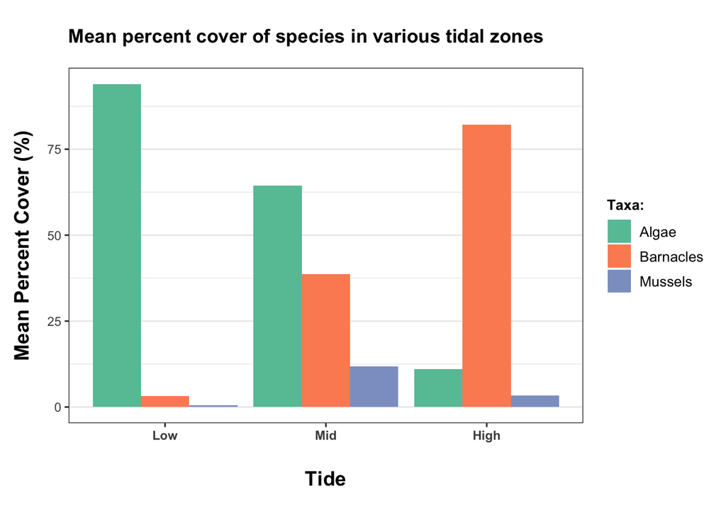

```r
# Create the bar plot
ggplot(summary_data, aes(x = fct_relevel(quadrat, "Low", "Mid", "High"), #fct relevel to manually assign levels
                         y = mean_percent_cover, fill = species)) +
  geom_bar(stat = "identity", position = "dodge") +
  scale_fill_brewer(palette = "Set2",) +  # use a color palette to differentiate species
  labs(x = "Tide", y = "Mean Percent Cover (%)", fill = "Taxa:", title = "Mean percent cover of species in various tidal zones") + #labels
  theme_bw() + #bw themes, cleannnn
  theme(
    legend.position = "right",
    legend.title = element_text(face = "bold", size = 10),  #bold legend title
    legend.text = element_text(size = 10),
    axis.text.x = element_text(face = "bold"), #bold
    plot.margin = margin(20, 10, 20, 10),
    axis.title = element_text(face = "bold"), #bold
    axis.title.x = element_text(margin = margin(t = 20), size = 14),  #space above x-axis title
    axis.title.y = element_text(margin = margin(r = 10), size = 14),  #space to the right of y-axis title
    plot.title = element_text(margin = margin(b = 15), face = "bold"),
    panel.grid.major.x = element_blank(),  #remove major horizontal grid lines
    panel.grid.minor.x = element_blank()  #remove minor horizontal grid lines
  )
```